```python
import pandas
import numpy
import seaborn
import matplotlib.pyplot as plt
%matplotlib inline
seaborn.set(color_codes=True)

import warnings
warnings.simplefilter(action = "ignore", category = FutureWarning)

data = pandas.read_csv("addhealth_pds.csv", low_memory = False)

## all variables explored in this research project ##
all_variables = ["AID","H1ED12","H1ED14","H1ED17","H1PF16","H1PF18","H1PF19","H1PF20","H1PF21","H1PF30","H1PF33",\
				"H1PF34","H1PF15","H1ID6","H1NR1","H1NR2"]

## Convert variables to numeric values ##
for x in data:
    data[x].convert_objects(convert_numeric = True)

##remove row with counts ##
## remove boys' data ##
data.drop( data[data["BIO_SEX"] != 2].index, axis = 0, inplace = True )
## remove irrelevant variables ##
data.drop( [x for x in data.columns if x not in all_variables], axis = 1, inplace = True )


#create data frame for controls
controls = pandas.DataFrame(data)

## remove girls who did not earn an A in math ##
data.drop( data[data["H1ED12"] != 1].index, axis = 0, inplace = True )
#data.drop("H1ED12", axis = 1, inplace = True)
## remove girls who did not earn an A in science ##
data.drop( data[data["H1ED14"] != 1].index, axis = 0, inplace = True )
#data.drop("H1ED14", axis = 1, inplace = True)
## remove girls who had trouble with homework more than a few times during previous school year ##
data.drop( data[data["H1ED17"] > 1].index, axis = 0, inplace = True )
#data.drop("H1ED17", axis = 1, inplace = True)
## remove girls with poor decision-making ##
data.drop( data[data["H1PF16"] < 4].index, axis = 0, inplace = True)
data.drop( data[data["H1PF16"] > 5].index, axis = 0, inplace = True)
#data.drop("H1PF16", axis = 1, inplace = True)
## remove girls who lack fact-gathering trait ##
data.drop( data[data["H1PF18"] > 2].index, axis = 0, inplace = True)
#data.drop("H1PF18", axis = 1, inplace = True)
## remove girls who are not pre-analytical ##
data.drop( data[data["H1PF19"] > 2].index, axis = 0, inplace = True)
#data.drop("H1PF19", axis = 1, inplace = True)
## remove girls who do not judge systematically ##
data.drop( data[data["H1PF20"] > 2].index, axis = 0, inplace = True)
#data.drop("H1PF20", axis = 1, inplace = True)
## remove girls who are not post-analytical ##
data.drop( data[data["H1PF21"] > 2].index, axis = 0, inplace = True)
#data.drop("H1PF21", axis = 1, inplace = True)

#fill controls data frame with girls who do not fit criteria of strong STEM potential
controls.drop(controls[controls["AID"].isin(data["AID"])].index, axis = 0, inplace = True)

print ( "The number of girls with strong STEM potential: ", len(data), "\n"
       "The number of girls in the control group: ",len(controls) )

## Academic Performance Variables ##
#math_skills = data["H1ED12"]
#science_skills = data["H1ED14"]
#acad_facility = data["H1ED17"]

## Cognitive Style Variables

# decision_making = data["H1PF16"]
# fact_gathering = data["H1PF18"]
# pre_anal = data["H1PF19"]
# syst_judg = data["H1PF20"]
# post_anal = data["H1PF21"]

## Self-Esteem Variables ##
stem_self_val = data["H1PF30"]
stem_self_appr = data["H1PF33"]
stem_self_judg = data["H1PF34"]

controls_self_val = controls["H1PF30"]
controls_self_appr = controls["H1PF33"]
controls_self_judg = controls["H1PF34"]

## Emotional Orientation Variables ##
stem_diff_resp = data["H1PF15"]
controls_diff_resp = controls["H1PF15"]

## Social Orientation Variables ##
stem_rela_int = data["H1ID6"]
stem_romantic_int = { "f": data["H1NR1"], "m": data["H1NR2"] }

controls_rela_int = controls["H1ID6"]
controls_romantic_int = { "f": controls["H1NR1"], "m": controls["H1NR2"] }

recode1 = {1:"SA", 2:"A", 3:"NAND", 4:"D", 5:"SD", 6:"R", 8:"DK", 9:"NA"}
stem_self_val = stem_self_val.map(recode1)
stem_self_appr = stem_self_appr.map(recode1)
stem_self_judg = stem_self_judg.map(recode1)

controls_self_val = controls_self_val.map(recode1)
controls_self_appr = controls_self_appr.map(recode1)
controls_self_judg = controls_self_judg.map(recode1)

stem_diff_resp = stem_diff_resp.map(recode1)
controls_diff_resp = controls_diff_resp.map(recode1)

recode2 = {0: "No", 1: "Yes", 6: "Refused", 8: "Don't Know", 9: "NA"}

for sex in stem_romantic_int.keys():
	stem_romantic_int[sex] = stem_romantic_int[sex].map(recode2)

for sex in controls_romantic_int.keys():
	controls_romantic_int[sex] = controls_romantic_int[sex].map(recode2)
```

```
The number of girls with strong STEM potential:  131
The number of girls in the control group:  3225
```

# Visualization of The Emotional Traits of Adolescent Girls with Strong STEM Potential in Comparison to Sex- and Age-Matched Controls

## Self-Esteem Variables

- SA: strongly agree
- A: agree
- NAND: neither agree nor disagree
- D: disagree
- SD: strongly disagree
- R: refused
- DK: don't know
- NA: not applicable

```python
stem_self_val = stem_self_val.astype('category')
stem_self_appr = stem_self_appr.astype('category')
stem_self_judg = stem_self_judg.astype('category')

controls_self_val = controls_self_val.astype('category')
controls_self_appr = controls_self_appr.astype('category')
controls_self_judg = controls_self_judg.astype('category')
```

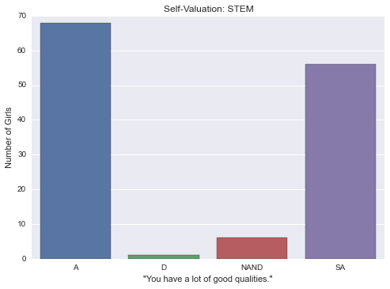

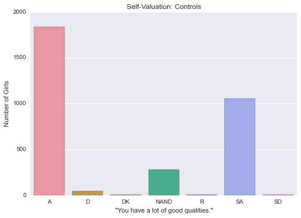

```python
seaborn.countplot(x = stem_self_val, data = None )
plt.xlabel("\"You have a lot of good qualities.\"")
plt.ylabel("Number of Girls")
plt.title("Self-Valuation: STEM")
plt.show()

seaborn.countplot( x = controls_self_val, data = None )
plt.xlabel("\"You have a lot of good qualities.\"")
plt.ylabel("Number of Girls")
plt.title("Self-Valuation: Controls")
plt.show()
```

Self-valuation seems to be slightly higher the STEM girls, nearly all of whom agreed or strongly agreed. Controls' responses show greater variation.

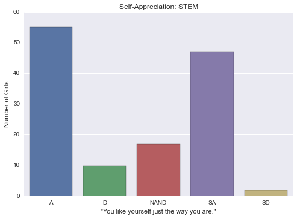

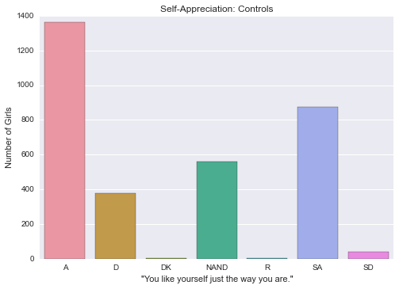

```python
seaborn.countplot( x = stem_self_appr, data = None )
plt.xlabel("\"You like yourself just the way you are.\"")
plt.ylabel("Number of Girls")
plt.title("Self-Appreciation: STEM")
plt.show()

seaborn.countplot( x = controls_self_appr, data = None )
plt.xlabel("\"You like yourself just the way you are.\"")
plt.ylabel("Number of Girls")
plt.title("Self-Appreciation: Controls")
plt.show()
```

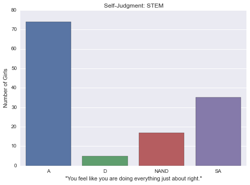

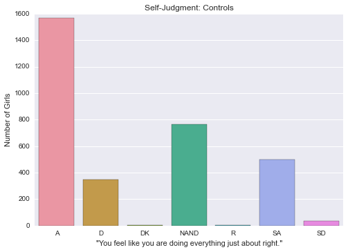

```python
seaborn.countplot( x = stem_self_judg, data = None )
plt.xlabel("\"You feel like you are doing everything just about right.\"")
plt.ylabel("Number of Girls")
plt.title("Self-Judgment: STEM")
plt.show()

seaborn.countplot( x = controls_self_judg, data = None )
plt.xlabel("\"You feel like you are doing everything just about right.\"")
plt.ylabel("Number of Girls")
plt.title("Self-Judgment: Controls")
plt.show()
```

Unlike the control group, the STEM group included no "strongly disagree" responses. Over 100 out of 131 STEM girls reported positive self-judgment ("agree" or "strongly agree"). Only about 2100 out of over three thousand controls reported positive self-judgment.

No one from the STEM group responded "don't know" to any of the three questionnaire items that make up the variables of the self-esteem factor. This may indicate greater self-assurance in comparison with controls.

## Emotional Orientation

I decided to remove the second emotional orientation variable (emotional staibility) because it was based on an unrealistic questionnaire item ("You never get sad.").

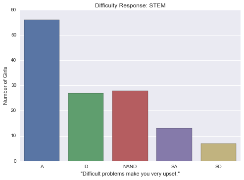

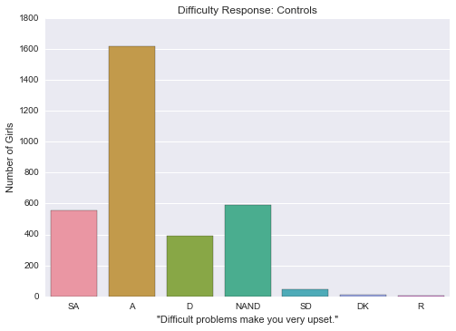

```python
stem_diff_resp = stem_diff_resp.astype('category')
seaborn.countplot( x = stem_diff_resp, data = None );
plt.xlabel("\"Difficult problems make you very upset.\"")
plt.ylabel("Number of Girls")
plt.title("Difficulty Response: STEM")
plt.show()

seaborn.countplot( x = controls_diff_resp, data = None )
plt.xlabel("\"Difficult problems make you very upset.\"")
plt.ylabel("Number of Girls")
plt.title("Difficulty Response: Controls")
plt.show()
```

## Social Orientation Variables

For the sake of brevity, I decided not to use the four-part variable relationship preferences in this research project. I also decided that the questionnaire items on which the variable was based were too detailed to be useful for a high-level exploration of emotional traits.

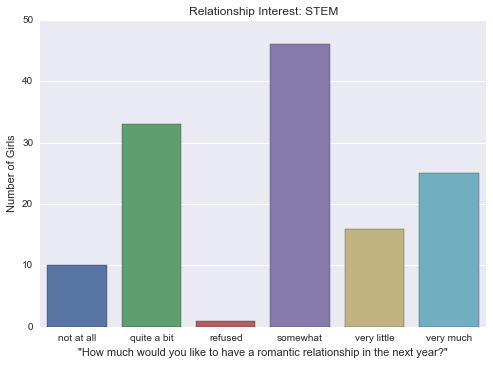

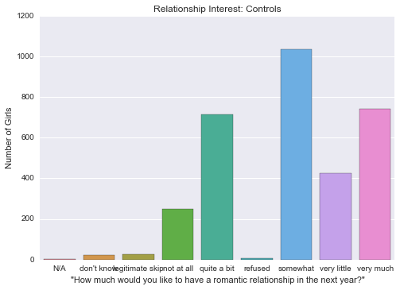

```python
recode3 = {1:"not at all", 2:"very little", 3:"somewhat", 4:"quite a bit", 5:"very much",\
           6:"refused", 7:"legitimate skip", 8:"don't know", 9:"N/A"}

stem_rela_int = stem_rela_int.map(recode3)
controls_rela_int = controls_rela_int.map(recode3)

stem_rela_int = stem_rela_int.astype('category')
controls_rela_int = controls_rela_int.astype('category')

stem_romantic_int["f"] = stem_romantic_int["f"].astype('category')
stem_romantic_int["m"] = stem_romantic_int["m"].astype('category')
controls_romantic_int["f"] = controls_romantic_int["f"].astype('category')
controls_romantic_int["m"] = controls_romantic_int["m"].astype('category')

seaborn.countplot( x = stem_rela_int, data = None )
plt.xlabel("\"How much would you like to have a romantic relationship in the next year?\"")
plt.ylabel("Number of Girls")
plt.title("Relationship Interest: STEM")
plt.show()

seaborn.countplot( x = controls_rela_int, data = None )
plt.xlabel("\"How much would you like to have a romantic relationship in the next year?\"")
plt.ylabel("Number of Girls")
plt.title("Relationship Interest: Controls")
plt.show()
```

About one-third of the girls in both groups reported uncertain interest in romantic relationships in the following year. Just under 50% of both groups expressed definite interest. Controls' responses showed greater variability.

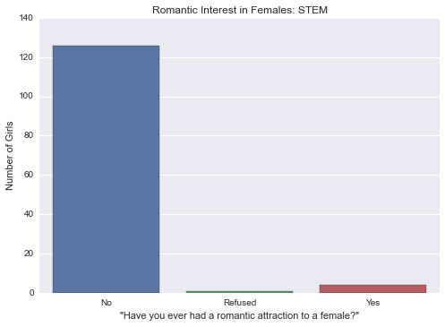

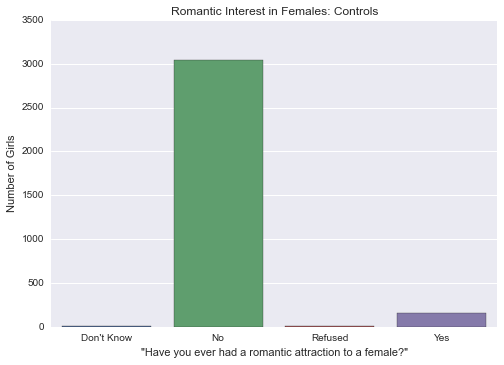

```python
seaborn.countplot( x = stem_romantic_int["f"], data = None )
plt.xlabel("\"Have you ever had a romantic attraction to a female?\"")
plt.ylabel("Number of Girls")
plt.title("Romantic Interest in Females: STEM")
plt.show()

seaborn.countplot( x = controls_romantic_int["f"], data = None )
plt.xlabel("\"Have you ever had a romantic attraction to a female?\"")
plt.ylabel("Number of Girls")
plt.title("Romantic Interest in Females: Controls")
plt.show()
```

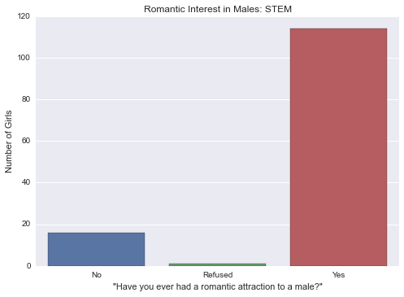

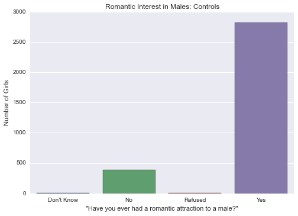

```python
seaborn.countplot( x = stem_romantic_int["m"], data = None )
plt.xlabel("\"Have you ever had a romantic attraction to a male?\"")
plt.ylabel("Number of Girls")
plt.title("Romantic Interest in Males: STEM")
plt.show()

seaborn.countplot( x = controls_romantic_int["m"], data = None )
plt.xlabel("\"Have you ever had a romantic attraction to a male?\"")
plt.ylabel("Number of Girls")
plt.title("Romantic Interest in Males: Controls")
plt.show()
```

In the case of attraction to males, the response distribution was equal for both groups (about 87% positive).

Among all responses I explored for this project (three self-esteem variables, one emotional orientation variable, and the above social orientation variables), the questionnaire items pertaining to the latter are the only ones that *any* girls in the STEM group refused to answer. At the same time, no girls from the STEM group responded "don't know" to any of the items in this project.

## Variable Relationships

The variables used to select the girls that make up the STEM group are the explanatory variables in this project. They are:

- grade in math
- grade in science
- whether or not the girl had trouble completing homework
- decision-making tendency
- fact-gathering tendency
- pre-analytical tendency
- systematic judging tendency
- post-analytical tendency

Please refer to the codebook (http://hlhodges.github.io/stem_girls/research_question.html) for greater detail.

The following code bins the response variables into two categories: 1, representing high, and 0, representing low.

```python
data2 = pandas.read_csv("addhealth_pds.csv", low_memory = False)
## convert response variables back to numeric ##
for x in all_variables:
    data2[x].convert_objects(convert_numeric = True)

## convert sex variable to numeric
data2['BIO_SEX'] = data2['BIO_SEX'].convert_objects(convert_numeric = True)
## remove boys' data ##
data2.drop( data2[data2["BIO_SEX"] != 2].index, axis = 0, inplace = True )
## remove irrelevant variables ##
data2.drop( [x for x in data2.columns if x not in all_variables], axis = 1, inplace = True )

## re-binning categorical response variables into two categories ##

## high self-esteem variables defined in terms of "agree" or "strongly agree" responses
def re_bin_val (val):
    if val["H1PF30"] < 3:
        return 1
    else:
        return 0

def re_bin_appr (val):
    if val["H1PF33"] < 3:
        return 1
    else:
        return 0

def re_bin_judg (val):
    if val["H1PF34"] < 3:
        return 1
    else:
        return 0

data2["H1PF30"] = data2.apply( lambda val: re_bin_val (val), axis = 1)
data2["H1PF33"] = data2.apply( lambda val: re_bin_appr (val), axis = 1)
data2["H1PF34"] = data2.apply( lambda val: re_bin_judg (val), axis = 1)

## low difficulty response and high relationship interest defined in terms of
## "agree"/"strongly agree" and "very much"/"quite a bit," respectively ##
def re_bin_diff (val):
    if val["H1PF15"] in [ 4, 5 ]:
        return 1
    else:
        return 0

def re_bin_rela (val):
    if val["H1ID6"] in [ 4, 5 ]:
        return 1
    else:
        return 0

data2["H1PF15"] = data2.apply( lambda val: re_bin_diff (val), axis = 1)
data2["H1ID6"] = data2.apply( lambda val: re_bin_rela (val), axis = 1)

## high romantic interest (in both males and females) defined in terms of "yes" responses
def re_bin_fem (val):
    if val["H1NR1"] == 1:
        return 1
    else:
        return 0
def re_bin_mal (val):
    if val["H1NR2"] == 1:
        return 1
    else:
        return 0
data2["H1NR1"] = data2.apply( lambda val: re_bin_fem (val), axis = 1)
data2["H1NR2"] = data2.apply( lambda val: re_bin_mal (val), axis = 1)
```

The following code recodes and re-bins the explanatory variables, removing unusable responses (skip, don't know, etc.). Refusals to respond are retained (coded equal to zero); the notable lack of refusals from girls in the STEM group suggests that exploring this response might provide insight.

Math grade, science grade, and difficulty with homework are combined in the variable Academic Performance and recoded such that higher numerical scores represent higher math and science grades and less difficulty with homework.

The other five explanatory variables are combined into the numerical variable Cognitive Style, which is coded such that higher scores represent stronger endorsement of a cognitive style that is assumed to be advantageous to STEM success.

```python
data2["H1ED12"] = data2["H1ED12"].replace( [5, 6, 97, 98 ], numpy.nan)
data2["H1ED14"] = data2["H1ED14"].replace( [5, 6, 97, 98 ], numpy.nan)
#recode_grades = {1:"A", 2:"B", 3:"C", 4:"D", 96:"refused"}
## recode so that higher grades correspond to higher response codes. refusal = 0 ##
recode_grades = {1:4, 2:3, 3:2, 4:1, 96:0}
data2["H1ED12"] = data2["H1ED12"].map(recode_grades)
data2["H1ED14"] = data2["H1ED14"].map(recode_grades)

data2["H1ED17"] = data2["H1ED17"].replace( [ 7, 8 ], numpy.nan)
#recode_hw = {0:"never", 1:"few times", 2:"1x/wk.", 3:"~daily", 4:"daily", 6:"refused"}
recode_hw = {0:5, 1:4, 2:3, 3:2, 4:1, 6:0}
data2["H1ED17"] = data2["H1ED17"].map(recode_hw)

recode_dec = {1:1, 2:2, 3:3, 4:4, 5:5, 6:0, 8:-1}
data2["H1PF16"] = data2["H1PF16"].map(recode_dec)
recode_cog = {1:5, 2:4, 4:2, 5:1, 6:0, 8:-1}
data2["H1PF18"] = data2["H1PF18"].map(recode_cog)
data2["H1PF18"] = data2["H1PF18"].replace(9, numpy.nan)
data2["H1PF19"] = data2["H1PF19"].map(recode_cog)
data2["H1PF20"] = data2["H1PF20"].map(recode_cog)
data2["H1PF21"] = data2["H1PF21"].map(recode_cog)

## create two new variables: academic performance and cognitive style $$
data2["H1ED12"] = data2["H1ED12"].dropna()
data2["H1ED14"] = data2["H1ED14"].dropna()
data2["H1ED17"] = data2["H1ED17"].dropna()
acad_perf = data2["H1ED12"] + data2["H1ED14"] + data2["H1ED17"]
acad_perf = acad_perf.dropna()

cog_style = data2["H1PF16"].dropna() + data2["H1PF18"].dropna() + data2["H1PF19"].dropna()\
                + data2["H1PF20"].dropna() + data2["H1PF21"].dropna()
cog_style = cog_style.dropna()

print("Academic Performance:\n ", acad_perf.value_counts(sort = False, normalize = True))
print("Cognitive Style:\n ", cog_style.value_counts(sort = False, normalize = True))
```

```
Academic Performance:
  3     0.004391
4     0.022503
5     0.029638
6     0.072448
7     0.109769
8     0.129528
9     0.190450
10    0.181668
11    0.157519
12    0.102086
dtype: float64
Cognitive Style:
  5     0.000542
9     0.007592
```

[output cut: 17 more lines]

### Academic Performance

#### Vs. Self-Esteem

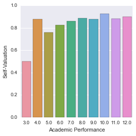

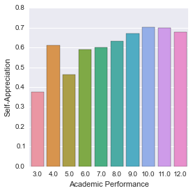

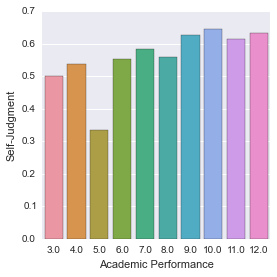

```python
data2["Acad"] = acad_perf
data2["Cog"] = cog_style

seaborn.factorplot( x = "Acad", y = "H1PF30", data = data2, kind = 'bar', ci = None)
plt.xlabel("Academic Performance")
plt.ylabel("Self-Valuation")

seaborn.factorplot( x = "Acad", y = "H1PF33", data = data2, kind = 'bar', ci = None)
plt.xlabel("Academic Performance")
plt.ylabel("Self-Appreciation")

seaborn.factorplot( x = "Acad", y = "H1PF34", data = data2, kind = 'bar', ci = None)
plt.xlabel("Academic Performance")
plt.ylabel("Self-Judgment")
plt.show()
```

There appears to be a only a slight correlation between good academic performance and high self-esteem, and the students in the third best academic performance bin reported the highest self-esteem.

#### Emotional Orientation

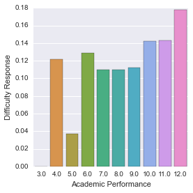

```python
seaborn.factorplot( x = "Acad", y = "H1PF15", data = data2, kind = 'bar', ci = None)
plt.xlabel("Academic Performance")
plt.ylabel("Difficulty Response")
plt.show()
```

As expected, the students with the best academic performance reported being the least upset by difficult problems.

#### Vs. Social Orientation

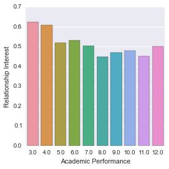

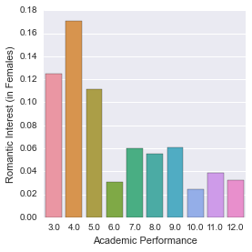

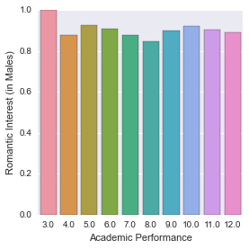

```python
seaborn.factorplot( x = "Acad", y = "H1ID6", data = data2, kind = 'bar', ci = None)
plt.xlabel("Academic Performance")
plt.ylabel("Relationship Interest")
plt.show()

seaborn.factorplot( x = "Acad", y = "H1NR1", data = data2, kind = 'bar', ci = None)
plt.xlabel("Academic Performance")
plt.ylabel("Romantic Interest (in Females)")
plt.show()

seaborn.factorplot( x = "Acad", y = "H1NR2", data = data2, kind = 'bar', ci = None)
plt.xlabel("Academic Performance")
plt.ylabel("Romantic Interest (in Males)")
plt.show()
```

### Cognitive Style

#### Vs. Self-Esteem

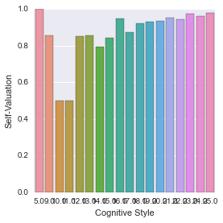

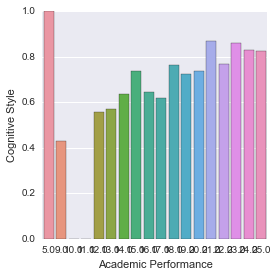

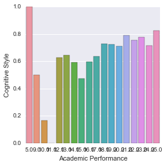

```python
seaborn.factorplot( x = "Cog", y = "H1PF30", data = data2, kind = 'bar', ci = None)
plt.xlabel("Cognitive Style")
plt.ylabel("Self-Valuation")

seaborn.factorplot( x = "Cog", y = "H1PF33", data = data2, kind = 'bar', ci = None)
plt.xlabel("Academic Performance")
plt.ylabel("Cognitive Style")

seaborn.factorplot( x = "Cog", y = "H1PF34", data = data2, kind = 'bar', ci = None)
plt.xlabel("Academic Performance")
plt.ylabel("Cognitive Style")
plt.show()
```

The girls with the lowest score pertaining to cognitive styles assumed to be advantageous to STEM success reported the highest self-esteem. Outside of this group, higher self-esteem appears to correlate with higher scores on these cognitive styles.

#### Vs. Emotional Orientation

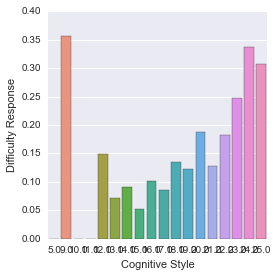

```python
seaborn.factorplot( x = "Cog", y = "H1PF15", data = data2, kind = 'bar', ci = None)
plt.xlabel("Cognitive Style")
plt.ylabel("Difficulty Response")
plt.show()
```

#### Vs. Social Orientation

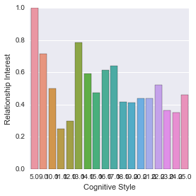

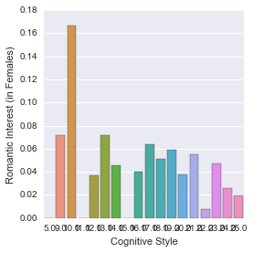

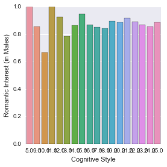

```python
seaborn.factorplot( x = "Cog", y = "H1ID6", data = data2, kind = 'bar', ci = None)
plt.xlabel("Cognitive Style")
plt.ylabel("Relationship Interest")
plt.show()

seaborn.factorplot( x = "Cog", y = "H1NR1", data = data2, kind = 'bar', ci = None)
plt.xlabel("Cognitive Style")
plt.ylabel("Romantic Interest (in Females)")
plt.show()

seaborn.factorplot( x = "Cog", y = "H1NR2", data = data2, kind = 'bar', ci = None)
plt.xlabel("Cognitive Style")
plt.ylabel("Romantic Interest (in Males)")
plt.show()
```